# Pseudotime analysis

Kristen Wells

August 08, 2022

## Setup

```r
library(Seurat)
library(tidyverse)
library(cowplot)
library(openxlsx)
library(here)
library(scAnalysisR)
library(psupertime)

source("src/scripts/functions.R")

# Set theme
ggplot2::theme_set(ggplot2::theme_classic(base_size = 10))

sample <- "All_combined"

sample_dir <- here("results", sample, "R_analysis")

psuper_obj_wt <- readRDS(file.path(sample_dir, "rda_obj", "wt_psupertime.rds"))

psuper_obj_cfko <- readRDS(file.path(sample_dir, "rda_obj",
                                     "cfko_psupertime.rds"))


sample_colors <- as.character(LaCroixColoR::lacroix_palette("Coconut", 10))
sample_colors[5] <- "#F4E3C7"
names(sample_colors) <- c("WT_D2", "WT_D5", "WT_D7", "WT_D9", "WT_D14",
                          "CFKO_D14", "CFKO_D9", "CFKO_D7", "CFKO_D5", "CFKO_D2")
sample_colors <- sample_colors[c("WT_D2", "WT_D5", "WT_D7", "WT_D9", "WT_D14",
                          "CFKO_D2", "CFKO_D5", "CFKO_D7", "CFKO_D9", "CFKO_D14")]

wt_sample_colors <- sample_colors[names(sample_colors) %in%
                                    c("WT_D2", "WT_D5", "WT_D7",
                                      "WT_D9", "WT_D14")]

wt_sample_colors_day <- wt_sample_colors
names(wt_sample_colors_day) <- gsub("WT_", "", names(wt_sample_colors_day))

cfko_sample_colors <- sample_colors[names(sample_colors) %in%
                                    c("CFKO_D2", "CFKO_D5", "CFKO_D7",
                                      "CFKO_D9", "CFKO_D14")]

cfko_sample_colors_day <- cfko_sample_colors
names(cfko_sample_colors_day) <- gsub("CFKO_", "", names(cfko_sample_colors_day))
```

# Quality plots

## WT

### Model diagnostics

The plot below shows how several measures of performance are affected by the extent of regularization, λ. The x-axis shows λ, indicating how strongly the model tries to set coefficients to zero. The optimal value of λ is the one which gives the best mean performance over the training data, based on one of two possible measures of performance.

The first row shows classification error, namely the proportion of cells for which psupertime predicted the wrong label (equivalent to 1 - accuracy). The second row is cross-entropy, which quantifies how confidently the psupertime classifier predicts the correct label (so predicting the correct label with probability p=0.9 results in a lower cross-entropy than with probability p=0.5). Accuracy is a ‘lumpy’ measurement of performance (something is either correct or not), whereas cross-entropy is continuous; this means that selecting λ on the basis of cross-entropy results in less noisy selection of the λ value.

The third row shows the number of genes with non-zero coefficients, for each given value of λ (this is effectively the inverse of sparsity, which is the proportion of zero coefficients).

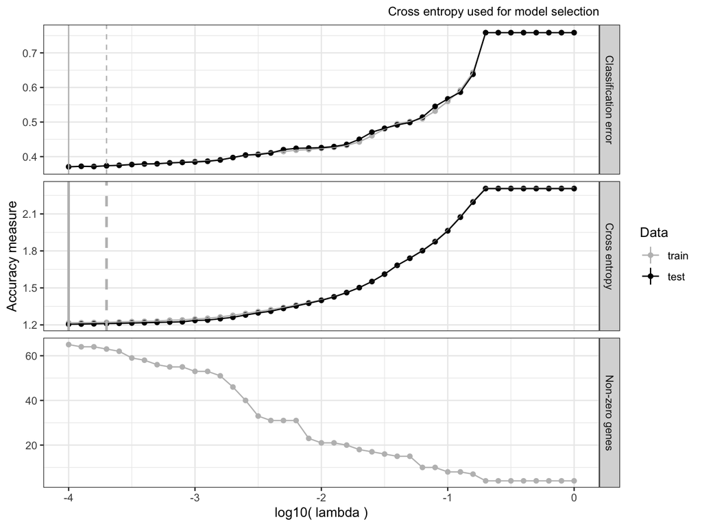

```r
g <- plot_train_results(psuper_obj_wt)

g
```

### Ordering of cells

Like other pseudotime methods, one output from psupertime is an ordering for the individual cells (shown below). In this case of psupertime, this ordering should broadly follow the group-level labels given as inputs.

Interesting things you might observe:

Individual cells may have earlier or later values than others with the same label, possibly suggesting interesting subpopulations within a group label. The thresholds learned by psupertime indicate how easy it is to distinguish between the different labels: where thresholds are close together, these labels are hard to separate, and where they are distant this task is easier.

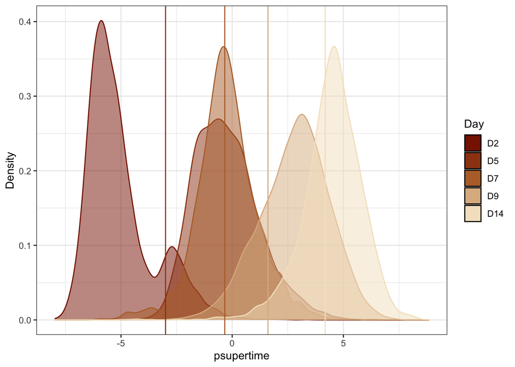

```r
g <- plot_labels_over_psupertime(psuper_obj_wt, label_name='Day')

g +
  scale_color_manual(values = wt_sample_colors_day) +
  scale_fill_manual(values = wt_sample_colors_day)
```

### Genes of interest

psupertime identifies a small set of genes which place the individual cells approximately in the order of the group-level labels. This list can be the most relevant output from psupertime. The plot below shows the 20 genes with the largest absolute coefficient values (subject to the absolute value being >0.05). Genes with positive coefficients will have expression positively correlated with the group-level labels, and vice versa for negative coefficients.

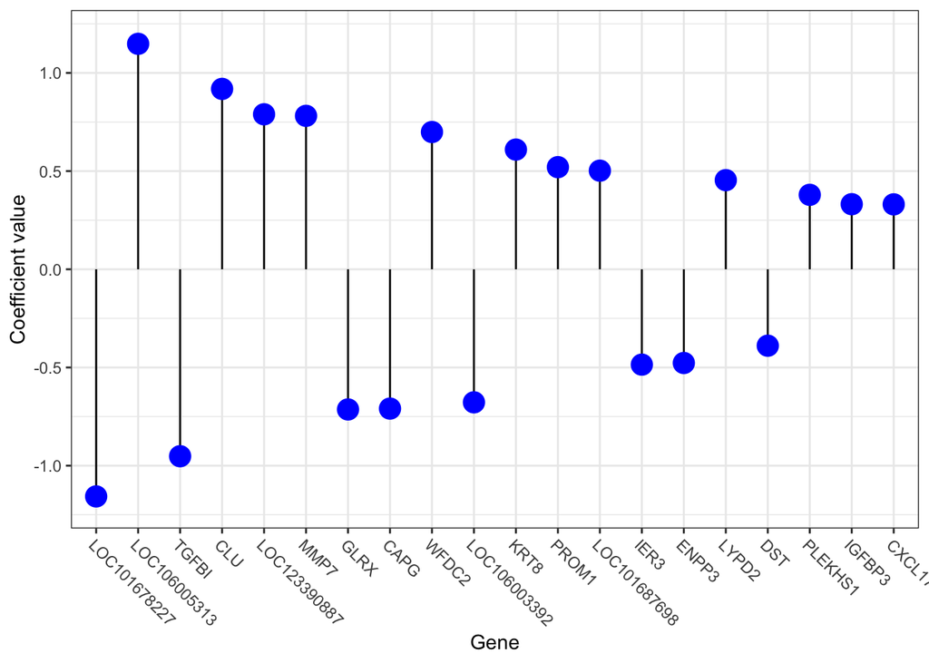

```r
g <- plot_identified_gene_coefficients(psuper_obj_wt)


g
```

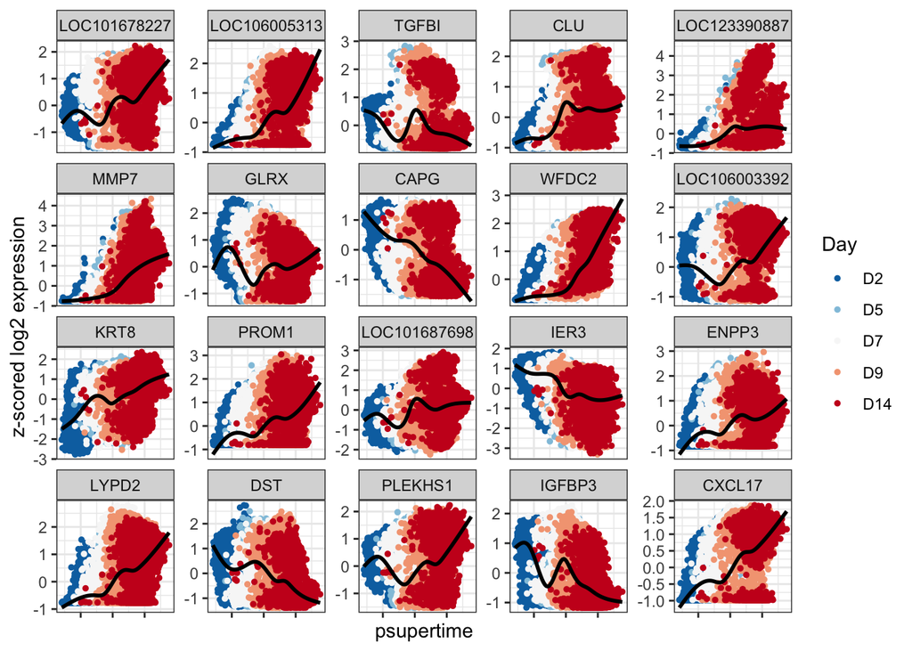

```r
g <- plot_identified_genes_over_psupertime(psuper_obj_wt,
                                           label_name='Day')
(g)
```

## CFKO

### Model diagnostics

The plot below shows how several measures of performance are affected by the extent of regularization, λ. The x-axis shows λ, indicating how strongly the model tries to set coefficients to zero. The optimal value of λ is the one which gives the best mean performance over the training data, based on one of two possible measures of performance.

The first row shows classification error, namely the proportion of cells for which psupertime predicted the wrong label (equivalent to 1 - accuracy). The second row is cross-entropy, which quantifies how confidently the psupertime classifier predicts the correct label (so predicting the correct label with probability p=0.9 results in a lower cross-entropy than with probability p=0.5). Accuracy is a ‘lumpy’ measurement of performance (something is either correct or not), whereas cross-entropy is continuous; this means that selecting λ on the basis of cross-entropy results in less noisy selection of the λ value.

The third row shows the number of genes with non-zero coefficients, for each given value of λ (this is effectively the inverse of sparsity, which is the proportion of zero coefficients).

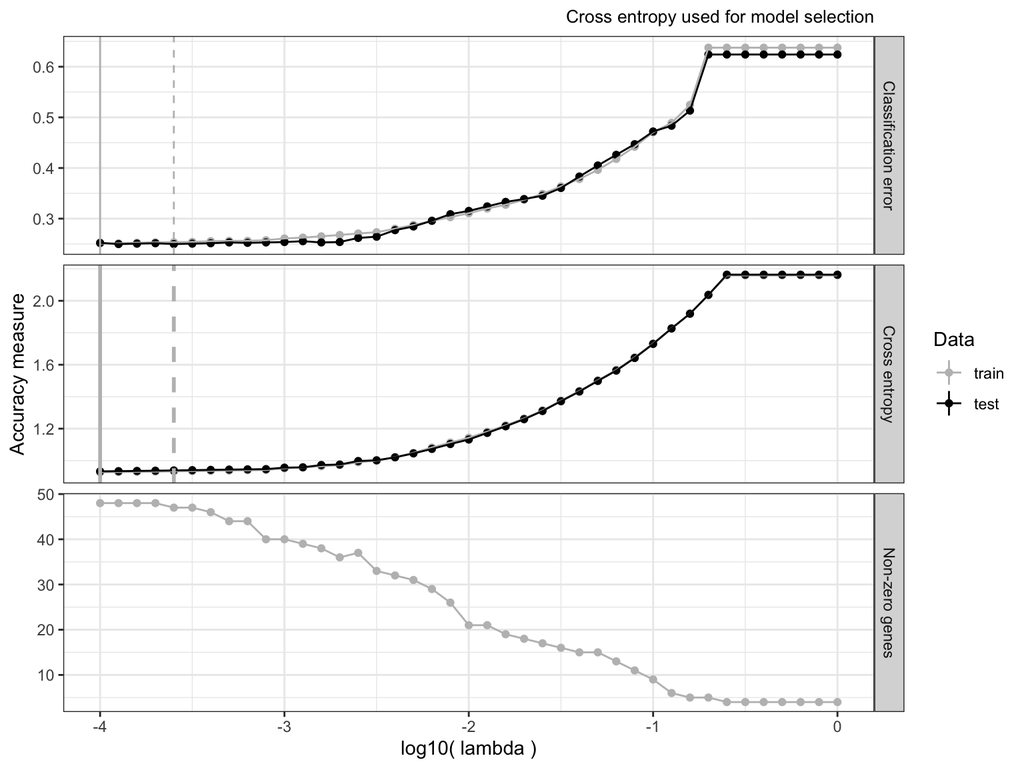

```r
g <- plot_train_results(psuper_obj_cfko)

g
```

### Ordering of cells

Like other pseudotime methods, one output from psupertime is an ordering for the individual cells (shown below). In this case of psupertime, this ordering should broadly follow the group-level labels given as inputs.

Interesting things you might observe:

Individual cells may have earlier or later values than others with the same label, possibly suggesting interesting subpopulations within a group label. The thresholds learned by psupertime indicate how easy it is to distinguish between the different labels: where thresholds are close together, these labels are hard to separate, and where they are distant this task is easier.

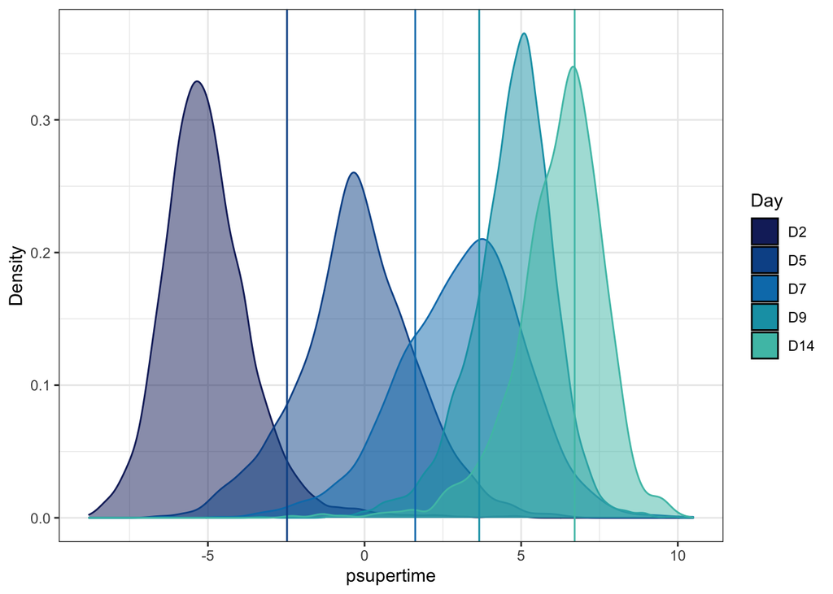

```r
g <- plot_labels_over_psupertime(psuper_obj_cfko, label_name='Day')

g +
  scale_color_manual(values = cfko_sample_colors_day) +
  scale_fill_manual(values = cfko_sample_colors_day)
```

### Genes of interest

psupertime identifies a small set of genes which place the individual cells approximately in the order of the group-level labels. This list can be the most relevant output from psupertime. The plot below shows the 20 genes with the largest absolute coefficient values (subject to the absolute value being >0.05). Genes with positive coefficients will have expression positively correlated with the group-level labels, and vice versa for negative coefficients.

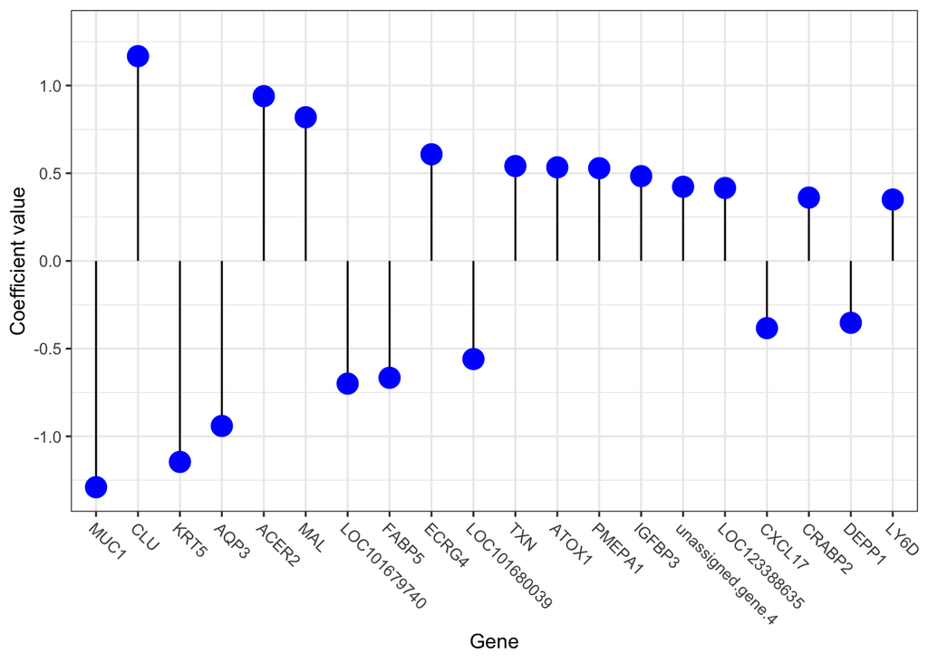

```r
g <- plot_identified_gene_coefficients(psuper_obj_cfko)


g
```

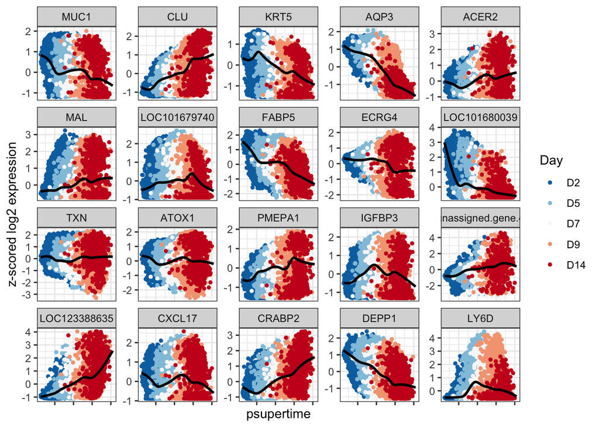

```r
g <- plot_identified_genes_over_psupertime(psuper_obj_cfko,
                                           label_name='Day')
(g)
```